# Poisson regression, sparsification, and model selection

Peter Ralph

29 January 2018 – Advanced Biological Statistics

# Overview

## Summary

*So far* we looked at fitting probabilities of *binary* events predicted by various sorts of explanatory variables - for instance, “logistic regression”.

Grouping means together using hyperpriors induced *shrinkage*, allowing sharing of information between groups.

*Simulation* is also useful for debugging and, vaguely, checking model fit.

## Next up

Next we’ll hit many of the same topics in a slightly different context: when the data are *counts* rather than *proportions*. (“How many birds are there?” instead of “How many of the birds are red?”)

We’ll also see how to use simulation to do *formal* model comparisons.

# Count data

## A hypothetical situation:

1. We have **counts** of transcript numbers,
2. from some individuals of different **ages** and past **exposures** to solar irradiation,
3. of two **genotypes**.

*Model:*

- Counts are **Poisson**,
- with mean that depends on age and exposure,
- but effect of exposure depends on genotype.
- But actually, counts are *overdispersed*, so make the means *random*, and lognormally distributed.
1. Counts are **Poisson**,
2. with mean that depends on age and exposure,
3. but effect of exposure depends on genotype.
4. But actually, counts are *overdispersed*, so make the means *random*, and lognormally distributed.

$$\begin{aligned}
Z_i &\sim \Poisson(\mu_i) \\
\end{aligned}$$

1. Counts are **Poisson**,
2. with mean that depends on age and exposure,
3. but effect of exposure depends on genotype.
4. But actually, counts are *overdispersed*, so make the means *random*, and lognormally distributed.

$$\begin{aligned}
Z_i &\sim \Poisson(\mu_i) \\
\mu_i &= a + b \times \text{age}_i + c \times \text{exposure}_i
\end{aligned}$$

1. Counts are **Poisson**,
2. with mean that depends on age and exposure,
3. but effect of exposure depends on genotype.
4. But actually, counts are *overdispersed*, so make the means *random*, and lognormally distributed.

$$\begin{aligned}
Z_i &\sim \Poisson(\mu_i) \\
\mu_i &= \exp\left( a_{g_i} + b \times \text{age}_i + c_{g_i} \times \text{exposure}_i \right)
\end{aligned}$$

1. Counts are **Poisson**,
2. with mean that depends on age and exposure,
3. but effect of exposure depends on genotype.
4. But actually, counts are *overdispersed*, so make the means *random*, and lognormally distributed.

$$\begin{aligned}
Z_i &\sim \Poisson(\mu_i) \\
\mu_i &= \exp(W_i) \\
W_i &\sim \Normal(y_i, \sigma) \\
y_i &= a_{g_i} + b \times \text{age}_i + c_{g_i} \times \text{exposure}_i
\end{aligned}$$

1. Counts are **Poisson**,
2. with mean that depends on age and exposure,
3. but effect of exposure depends on genotype.
4. But actually, counts are *overdispersed*, so make the means *random*, and lognormally distributed.

$$\begin{aligned}
Z_i &\sim \Poisson(\mu_i) \\
\mu_i &\sim \log\Normal(y_i, \sigma) \\
y_i &= a_{g_i} + b \times \text{age}_i + c_{g_i} \times \text{exposure}_i
\end{aligned}$$

## Simulate these and compare.

$$\begin{aligned}
Z_i &\sim \Poisson(\mu_i) \\
\mu_i &= \exp\left(a_{g_i} + b \times \text{age}_i \right.\\
&\qquad \left. {}
+ c_{g_i} \times \text{exposure}_i \right)
\end{aligned}$$

$$\begin{aligned}
Z_i &\sim \Poisson(\mu_i) \\
\mu_i &= \exp(X_i) \\
X_i &\sim \Normal(y_i, \sigma) \\
y_i &= a_{g_i} + b \times \text{age}_i \\
&\qquad {}
+ c_{g_i} \times \text{exposure}_i
\end{aligned}$$

## Simulate this.

```r
true_params <- list(a=c(0, 0.2),
                    b=1/20,
                    c=c(1/30, -1/15),
                    sigma=1.0)
nsamples <- 500
data <- data.frame(genotype=sample(c(1,2), nsamples,
                                   replace=TRUE),
                   age = rgamma(nsamples, 3, 0.1),
                   exposure = rexp(nsamples, 0.2))
data$y <- with(data, true_params$a[genotype] +
                      true_params$b * age +
                      true_params$c[genotype] * exposure)
data$mu <- exp(rnorm(nrow(data), mean=data$y,
                     sd=true_params$sigma))
data$counts <- rpois(nsamples, data$mu)
```

$$\begin{aligned}
Z_i &\sim \Poisson(\mu_i) \\
\mu_i &\sim \log\Normal(y_i, \sigma) \\
y_i &= \exp\left(a_{g_i} + b \times \text{age}_i \right.\\
&\qquad \left. {}
+ c_{g_i} \times \text{exposure}_i \right)
\end{aligned}$$

## Write a Stan block

1. Counts are **Poisson**,
2. with mean that depends on age and exposure,
3. but effect of exposure depends on genotype;
4. means are *random*, and lognormally distributed.

$$\begin{aligned}
Z_i &\sim \Poisson(\mu_i) \\
\mu_i &\sim \log\Normal(y_i, \sigma) \\
y_i &= a_{g_i} + b \times \text{age}_i \\
&\qquad {} + c_{g_i} \times \text{exposure}_i
\end{aligned}$$

```
data {
    // what we know
}
parameters {
    // what we want to find out
}
model {
    // how they relate
}
```

## The result

1. Counts are **Poisson**,
2. with mean that depends on age and exposure,
3. but effect of exposure depends on genotype;
4. means are *random*, and lognormally distributed.

$$\begin{aligned}
Z_i &\sim \Poisson(\mu_i) \\
\mu_i &\sim \log\Normal(y_i, \sigma) \\
y_i &= a_{g_i} + b \times \text{age}_i \\
&\qquad {} + c_{g_i} \times \text{exposure}_i
\end{aligned}$$

```
new_block <- "data {
    int N; // number of obs
    vector[N] age;
    int geno[N];
    vector[N] expo;
    int counts[N];
    int ngeno;
}
parameters {
    real<lower=0> mu[N]; // per-indiv 'mean'
    vector[ngeno] a;
    real b;
    vector[ngeno] c;
    real<lower=0> sigma;
}
model {
    vector[N] y;
    y = a[geno] + b * age + c[geno] .* expo;
    // for (i in 1:N) {
    //     y[i] = a[geno[i]] + b * age[i] + c[geno[i]] * expo[i];
    // }
    counts ~ poisson(mu);
    mu ~ lognormal(y, sigma);
    a ~ normal(0, 10);
    b ~ normal(0, 10);
    c ~ normal(0, 10);
    sigma ~ normal(0, 10);
}"

data_list <- list(
            N = nrow(data),
            age = data$age,
            geno = data$genotype,
            expo = data$exposure,
            counts = data$counts,
            ngeno = length(unique(data$genotype)))



new_fit <- stan(model_code=new_block,
             data=data_list,
             control=list(max_treedepth=12),
             iter=100, chains=3)
```

# Stochastic minute

## The Poisson distribution

If $N \sim \Poisson(\mu)$ then $N \ge 0$ and
$$\begin{aligned}
\P\{N = k\} = \frac{\mu^k}{k!} e^{-\mu}
\end{aligned}$$

- $N$ is a nonnegative integer (i.e., a *count*)
- $\E[N] = \var[N] = \mu$
- If a machine makes widgets very fast, producing on average one broken widget per minute (and many good ones), each breaking independent of the others, then the number of broken widgets in $\mu$ minutes is $\Poisson(\mu)$.
- If busses arrive randomly every $\Exp(1)$ minutes, then the number of busses to arrive in $\mu$ minutes is $\Poisson(\mu)$.

# Two models

## Step back: a simple model

Forget that we know how the data were generated.

Let’s fit a *standard* Poisson model.

```r
simple_block <- "
data {
    int N;
    int counts[N];
    vector[N] age;
    vector[N] exposure;
    int genotype[N];  // between 0 and 1
}
parameters {
    vector[2] a;
    real b;
    vector[2] c;
}
model {
    vector[N] mu;
    mu = exp(a[genotype] + b * age
             + c[genotype] .* exposure);
    counts ~ poisson(mu);
    a ~ normal(0, 5);
    b ~ normal(0, 5);
    c ~ normal(0, 5);
}"
```

*Note:* scaling the data helps Stan find the right scale to move on.

```r
scaled_data <- with(data, list(N=length(counts),
                               counts=counts,
                               age=(age - mean(age))/sd(age),
                               exposure=(exposure - mean(exposure))/sd(exposure),
                               genotype=genotype))
fit1 <- stan(model_code=simple_block,
             data=scaled_data,
             control=list(max_treedepth=12),
             iter=1000, chains=3)
```

```r
post1 <- extract(fit1)
print(fit1)
```

```
## Inference for Stan model: e04ed23635a1fc5cf9233f0866bdf5cf.
## 3 chains, each with iter=1000; warmup=500; thin=1;
## post-warmup draws per chain=500, total post-warmup draws=1500.
##
##          mean se_mean   sd     2.5%      25%      50%      75%    97.5%
## a[1]     2.24    0.00 0.02     2.20     2.22     2.24     2.25     2.28
## a[2]     1.58    0.00 0.03     1.53     1.56     1.58     1.60     1.64
## b        0.91    0.00 0.01     0.89     0.90     0.91     0.92     0.93
## c[1]     0.13    0.00 0.01     0.10     0.12     0.13     0.14     0.16
## c[2]    -0.38    0.00 0.03    -0.44    -0.40    -0.38    -0.36    -0.32
## lp__ 13445.48    0.08 1.67 13441.29 13444.65 13445.85 13446.71 13447.62
##      n_eff Rhat
## a[1]  1079    1
## a[2]  1260    1
## b     1298    1
## c[1]  1500    1
## c[2]  1500    1
## lp__   489    1
##
## Samples were drawn using NUTS(diag_e) at Mon Jan 29 22:36:19 2018.
## For each parameter, n_eff is a crude measure of effective sample size,
## and Rhat is the potential scale reduction factor on split chains (at
## convergence, Rhat=1).
```

## Aside: what happens during “warmup”?

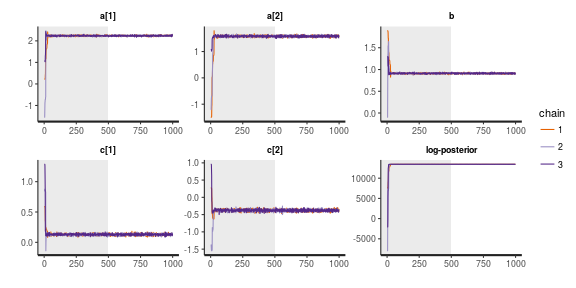

```r
stan_trace(fit1, pars=c("a","b","c","lp__"), inc_warmup=TRUE)
```

## The usual plot (without warmup)

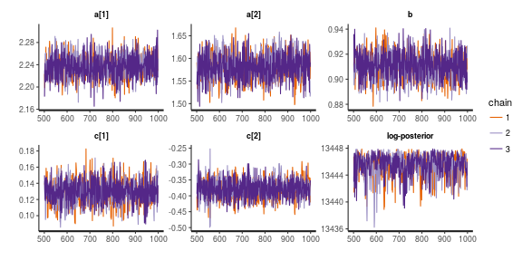

```r
stan_trace(fit1, pars=c("a","b","c","lp__"), inc_warmup=FALSE)
```

## How’d we do?

Here are posterior distributions of the parameters, with the true values in red.

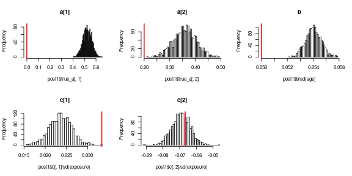

*What happened?*

## Goodness of fit

Let’s simulate up data *under this model* to check for goodness of fit.

We expect to **not** see a good fit. (*Why?*)

## 100 datasets from the posterior distribution

```r
params1 <- list(a=colMeans(post1$a),
                b=mean(post1$b),
                c=colMeans(post1$c))
mu1 <- with(list2env(scaled_data),
                  exp(params1$a[genotype]
                      + params1$b * age
                      + params1$c[genotype] * exposure))
# 100 datasets:
sim1 <- replicate(100, rpois(length(mu1), mu1))
```

```
model {
    vector[N] mu;
    mu = exp(a[genotype]
             + b * age
             + c[genotype]
               .* exposure);
    counts ~ poisson(mu);
```

## The true data are overdispersed relative to our simulations

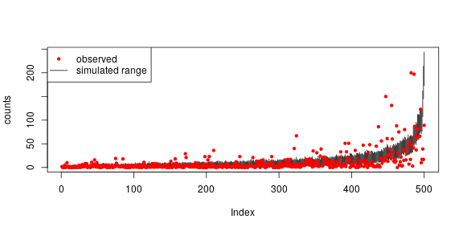

```r
plot(data$counts[order(mu1)], ylab="counts", ylim=range(sim1), type='n')
segments(x0=seq_len(nrow(data)),
         y0=rowMins(sim1)[order(mu1)],
         y1=rowMaxs(sim1)[order(mu1)])
points(data$counts[order(mu1)], pch=20, col='red')
legend("topleft", pch=c(20,NA), lty=c(NA,1), legend=c("observed", "simulated range"), col=c('red', 'black'))
```

## Including overdispersion

A *random mean* adds a level of randomness

```r
full_block <- "
data {
    int N;
    int counts[N];
    vector[N] age;
    vector[N] exposure;
    int genotype[N];
}
parameters {
    vector[2] a;
    real b;
    vector[2] c;
    vector<lower=0>[N] mu;
    real<lower=0> sigma;
}
model {
    vector[N] y;
    y = a[genotype] + b * age + c[genotype] .* exposure;
    counts ~ poisson(mu);
    mu ~ lognormal(y, sigma);
    a ~ normal(0, 5);
    b ~ normal(0, 5);
    c ~ normal(0, 5);
    sigma ~ normal(0, 5);
}"
```

```r
fit2 <- stan(model_code=full_block,
             data=scaled_data,
             iter=1000, chains=3)
```

```r
post2 <- extract(fit2)
print(fit2)
```

```
## Inference for Stan model: cc2fed94df9d2f003676a260a7adbf8e.
## 3 chains, each with iter=1000; warmup=500; thin=1;
## post-warmup draws per chain=500, total post-warmup draws=1500.
##
##             mean se_mean    sd     2.5%      25%      50%      75%
## a[1]        1.45    0.00  0.08     1.29     1.39     1.44     1.50
## a[2]        1.27    0.00  0.08     1.12     1.22     1.27     1.33
## b           0.91    0.00  0.05     0.81     0.87     0.91     0.94
## c[1]        0.13    0.00  0.07    -0.01     0.08     0.12     0.17
## c[2]       -0.40    0.00  0.09    -0.58    -0.46    -0.40    -0.33
## mu[1]       3.81    0.04  1.68     1.23     2.60     3.58     4.70
## mu[2]       3.00    0.04  1.62     0.82     1.84     2.68     3.80
## mu[3]       5.43    0.06  2.20     1.97     3.89     5.14     6.67
## mu[4]      12.72    0.09  3.43     6.82    10.32    12.43    14.77
## mu[5]       1.90    0.03  1.13     0.43     1.09     1.64     2.44
## mu[6]      45.07    0.17  6.69    33.06    40.68    44.60    49.57
## mu[7]       3.90    0.05  1.92     1.30     2.51     3.55     4.90
## mu[8]       1.12    0.02  0.78     0.20     0.55     0.93     1.46
## mu[9]       2.55    0.03  1.32     0.72     1.60     2.29     3.25
## mu[10]     20.51    0.11  4.39    12.82    17.31    20.30    23.26
## mu[11]      0.66    0.01  0.56     0.08     0.29     0.51     0.83
## mu[12]      0.64    0.01  0.54     0.08     0.26     0.49     0.84
## mu[13]      1.44    0.02  0.95     0.29     0.76     1.22     1.88
## mu[14]      2.03    0.03  1.18     0.48     1.18     1.76     2.62
## mu[15]     16.23    0.10  3.94     9.33    13.46    15.82    18.82
## mu[16]    642.68    0.66 25.72   595.43   625.25   641.75   659.83
## mu[17]      1.30    0.02  0.86     0.23     0.69     1.09     1.68
## mu[18]      1.48    0.02  0.94     0.31     0.80     1.27     1.96
## mu[19]      6.30    0.06  2.34     2.48     4.66     6.04     7.59
## mu[20]      1.86    0.03  1.15     0.38     1.01     1.62     2.45
## mu[21]      5.58    0.06  2.23     2.20     3.91     5.24     7.00
## mu[22]      3.11    0.04  1.52     0.96     2.03     2.84     3.95
## mu[23]      3.15    0.04  1.51     0.93     2.02     2.91     4.06
## mu[24]     38.38    0.16  6.22    27.45    33.92    37.99    42.45
## mu[25]      2.46    0.04  1.41     0.61     1.46     2.17     3.10
## mu[26]      1.32    0.02  0.90     0.25     0.68     1.10     1.76
## mu[27]      5.05    0.06  2.14     1.87     3.43     4.71     6.31
## mu[28]      4.29    0.05  1.95     1.37     2.90     4.01     5.27
## mu[29]      3.14    0.04  1.59     0.94     1.91     2.85     4.07
## mu[30]      3.40    0.04  1.65     1.09     2.20     3.09     4.20
```

[output cut: 970 more lines]

[output not shown]

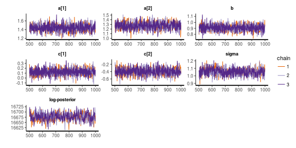

```r
stan_trace(fit2, pars=c("a", "b", "c", "sigma", "lp__"))
```

## How’d we do *now*?

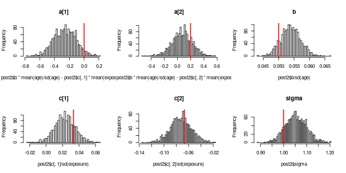

## Posterior predictive simulations, again

```r
# 100 datasets:
kk <- sample.int(nrow(post2$a), 100)
sims <- lapply(kk, function (k) {
                a <- post2$a[k,]
                b <- post2$b[k]
                c <- post2$c[k,]
                sigma <- post2$sigma[k]
                y <- with(list2env(scaled_data),
                          a[genotype] +
                          b * age +
                          c[genotype] * exposure)
                mu <- exp(rnorm(length(y),
                                mean=y, sd=sigma))
                rpois(length(mu), mu)
         })
sim2 <- do.call(cbind, sims)
```

```
model {
    vector[N] y;
    y = a[genotype] + b * age + c[genotype] .* exposure;
    counts ~ poisson(mu);
    mu ~ lognormal(y, sigma);
}
```

## Now we cover the true data

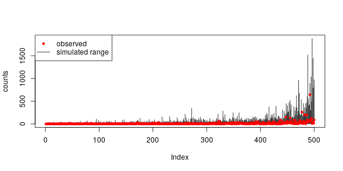

```r
plot(data$counts[order(mu1)], ylab="counts", ylim=range(sim2), type='n')
segments(x0=seq_len(nrow(data)),
         y0=rowMins(sim2)[order(mu1)],
         y1=rowMaxs(sim2)[order(mu1)])
points(data$counts[order(mu1)], pch=20, col='red')
legend("topleft", pch=c(20,NA), lty=c(NA,1), legend=c("observed", "simulated range"), col=c('red', 'black'))
```

# Model comparison

## How to *compare* the two models?

Two models:

1. `counts ~ poisson(exp(a + b * age + c * exposure))`
2. `counts ~ poisson(logNormal(a + b * age + c * exposure))`

We just saw some plots that showed that the true data lay outside the range of the simulated data from (1) but not (2).

That was *not* a formal test.

## We need a statistic!

*Brainstorm:* how can we quantify what we just saw?

*Goal:* come up with a single number that quantifies how much the observed data “looks like” the posterior predictive samples.

*Then,* the model with a better score *fits* better.

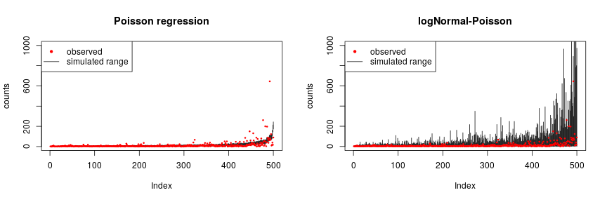

Same plot, zoomed in:

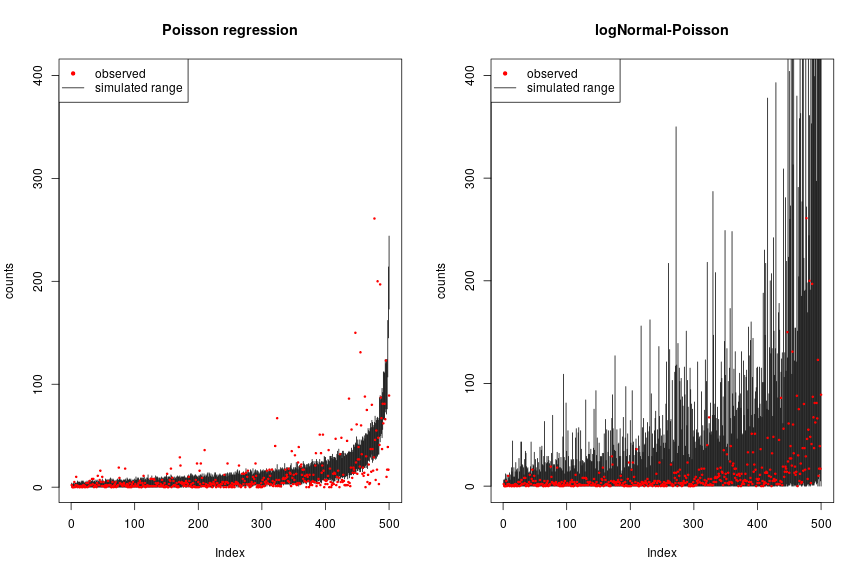

## Implementation

```r
gof <- function (z, x) {
    # z is a vector of observed counts
    # x is a (length(z) x N) matrix of simulated data
    sqrt(mean( ((z - rowMeans(x)) / rowSds(x))^2 ))
}
# TEST THIS
z0 <- rnorm(5); x0 <- matrix(rnorm(50), nrow=5)
ans0 <- gof(z0, x0)
ans1 <- 0
for (i in 1:5) {
    ans1 <- ans1 + (z0[i] - mean(x0[i,]))^2 / var(x0[i,])
}
ans1 <- sqrt(ans1/length(z0))
stopifnot(abs(ans0 - ans1) < 5*.Machine$double.eps)

gof_simple <- gof(data$counts, sim1)
gof_full <- gof(data$counts, sim2)
```

The “simple” model, that did not model overdispersion has a goodness of fit score of 4.6615927, substantially larger than the lognormal model, which had a score of 1.0362712. The score communicates how far the observed data are from the mean of the simulated data, in units of standard deviations.

## But does the model fit?

To see if model 2 actually *does* describe the data well, we’ll find the distribution of goodness-of-fit scores based on simulation: simulate some *more* datasets, compute the GOF score for each, and see where the observed value lies within that distribution.

On the next slide is a histogram of 100 GOF scores from simulated data; the red line shows the observed value.

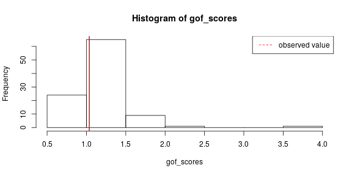

```r
more_sim2 <- do.call(cbind, sims)

gof_scores <- sapply(1:ncol(more_sim2), function (k) {
                         z <- more_sim2[,k]
                         x <- sim2
                         gof(z, x)
         } )
hist(gof_scores)
abline(v=gof_full, col='red', lwd=2)
legend("topright", lty=2, col='red', legend="observed value")
```

# Stan interlude

## The important program blocks

```
data {
    // what we know: the input
    // declarations only
}
parameters {
    // what we want to know about:
    // defines the space Stan random walks in
    // declarations only
}
model {
    // stuff to calculate the priors and the likelihoods
    // happens every step
}
```

## The program blocks

```
functions {
    // user-defined functions
}
data {
    // what we know: the input
    // declarations only
}
transformed data {
    // calculations to do once, at the start
}
parameters {
    // what we want to know about:
    // defines the space Stan random walks in
    // declarations only
}
transformed parameters {
    // other things that we want the posterior distribution of
    // happens every step
}
model {
    // stuff to calculate the priors and the likelihoods
    // happens every step
}
generated quantities {
    // more things we want the posterior distribution of
    // but that don't affect the random walk
}
```

## On priors

Under the hood,

```
    z ~ poisson(mu);
```

is equivalent to

```
    target += poisson_lpdf(z | mu);
```

(`lpdf` = log posterior density function).

So, if you *don’t* put a prior on something, it implicitly has a *uniform* prior (i.e., a flat prior).

## Error messages

These are important. Pay attention to them, and fix the problems.

## Parameterization matters

More on this later.